# 软件相关操作

Jin’s students

2019-03-03

**Table of Contents**

- 说明
- Windows系统中环境变量及其修改方法
  - 环境变量
  - Windows 系统中环境变量修改方法
    - 修改方法一：使用命令行
    - 修改方法二：使用 Rapidee 软件
    - 修改方法三：使用鼠标操作
- 软件准备
  - 软件列表
  - 安装pandoc
  - 安装Git程序并设置环境变量
- GitHub相关操作
  - 注册
  - GitHub嵌入Rstudio中需要做的工作
    - Rstudio中设置
  - 克隆项目：如何在Rstudio中克隆项目
  - 合作者步骤
  - 创建项目：把本地文件夹用git控制并push到Github的步骤
- article 项目模板
  - 使用方法
  - 模板文件结构
- 写作准备
- 文本注意事项
- 代码注意事项
- 编码注意事项
- Bib文件如何整理
  - 参考文献管理软件 Jabref
    - 功能
    - 安装
    - 知网文献导入步骤
    - Jabref操作
  - 整理bib文件注意事项
  - 如何运用VSCODE在论文中引用参考文献
  - 参考文献列出所有bib文件中条目方法
- Equalx的设置和用法
- Mathtype的设置和用法
- Rstudio生成bookdown pdf步骤
- 参考文献

**TODO**

- 表格出不来
- Bib文件如何整理
- 把1、等改成1. ，以变成 markdown list
- bibtexkey设置.png 调整

# 1 说明

1. 更完整的页面见本项目中的 [`README.html`](https://github.com/jinlin82/Rmarkdown-writing/raw/master/README.html)( 该链接另存为或克隆项目后在浏览器中打开)
2. 模板支持见项目 rmd-article-template 和项目 rmd-zuel-thesis-template.

# 2 Windows系统中环境变量及其修改方法

## 2.1 环境变量

环境变量一般是指在操作系统中用来指定操作系统运行环境的一些参数，当运行某程序时，除了在当前文件夹中寻找外，还会到设置的默认路径中去查找。更改环境变量就是设置“Path”。

## 2.2 Windows 系统中环境变量修改方法

### 2.2.1 修改方法一：使用命令行

- 把本项目中 `files` 文件夹中的 `showpath.bat`, `addpath.bat`, `SetEnv.exe` 三个文件拷贝到 `C:\Windows` 文件夹里面去
- 显示当前 `PATH` 环境变量方法：
  - 按下快捷键 `win+R` ，在弹出的窗口中输入 `CMD`，之后在弹出的窗口中输入： `showpath` 可以查看当前 `PATH` 环境变量设置
- 增加某个文件夹到 `PATH` 环境变量方法：
  - 进入要拷贝到的目标文件夹
  - 键盘敲入 `Alt+d` 然后输入 `addpath` 再回车即可

### 2.2.2 修改方法二：使用 Rapidee 软件

- 可以使用下面的 Rapidee 软件方便更改环境变量

### 2.2.3 修改方法三：使用鼠标操作

- 右击“我的电脑”，选择属性，找到并打开“高级系统配置”，找到“环境变量”按钮并点击。
- 环境变量窗口中有两个变量，一个是当前所使用用户独有的环境变量，另一个是所有用户都可以访问的系统变量。私人电脑若不设置新用户，二者都可以。在系统变量显示框中找到变量Path,选中并点击修改即可。
- 修改完毕之后全部点击确定，以保存修改的内容。一个路径与另一个路径之间要用分号隔开。

# 3 软件准备

## 3.1 软件列表

1. Rstudio 1.2 版本以上 [下载网址](https://www.rstudio.com/products/rstudio/download/preview/) 和 R 3.5.1 （必备）
2. Pandoc 2.7 版本 和 pandoc-crossref（必备）
3. Git （必备）
4. GitHub 网站账号 （必备）
5. Jabref(需要 jre 支持)
6. mathtype
7. equalx（需要 texlive 支持）
8. Rapidee（用于修改环境变量）

## 3.2 安装pandoc

1. 下载2.7版本pandoc
2. 下载pandoc-crossref [下载网站](https://github.com/lierdakil/pandoc-crossref/releases/download/v0.3.4.0d/windows-x86_64-pandoc_2.7.zip)
3. 将解压出来的 pandoc.exe, pandoc-citeproc.exe, pandoc-crossref.exe 拷贝替换到 rstudio 安装文件夹里面的 `bin\pandoc\` 文件夹里面（确认这个文件夹含有pandoc.exe）
4. 重启rstudio，重新生成html文件和docx文件，该文件支持公式编号。

## 3.3 安装Git程序并设置环境变量

按照Windows中更改环境变量的步骤，在“Path”中将Git文件夹下的bin所在路径添加到后面即可，注意路径之间用分号隔开。

# 4 GitHub相关操作

## 4.1 注册

网页操作https://github.com

## 4.2 GitHub嵌入Rstudio中需要做的工作

### 4.2.1 Rstudio中设置

在Rstudio中菜单栏点击Tools→Global Options，在弹出的对话框左边一栏点击Git/SVN，在Git executable中输入git.exe所在路径，点击ok

按下快捷键win+R，在弹出的窗口中输入CMD，之后在弹出的窗口中输入：

```
git config --global user.email "380906952@qq.com"
git config --global user.name "Zeng Yuanzheng"
```

（注：引号里改为自己的邮箱和名字，名字用汉语拼音写）

## 4.3 克隆项目：如何在Rstudio中克隆项目

1. 在Rstudio中，点击file→new project→version control→git，在弹出的对话框中， Repository URL输入项目链接，
2. Project directory name输入项目名字（一般写入项目链接后会自动生成），Create project as subdirectory of中输入自己电脑上要把项目保存的位置，点击Create Project，项目创建完毕。
3. 之后会在Rstudio右下角显示出项目里的所有内容。

## 4.4 合作者步骤

1. repository owner向合作者发出邀请（repository setting）
2. 被邀请者在网页（https://github.com/username/reponame/invitations) 接受邀请，成为合作者（注：uername为帐户名，reponame为项目名）
3. 合作者clone 项目到本地repository
4. 打开项目中的.Rmd，对文件中的内容进行修改（Modified），修改完之后点击保存（Save），在git图标下点击commit，在弹出的窗口中，左上角勾选刚刚修改的Rmd文件，右上角登记(Stage)修改的内容（比如，在Rmd中修改了图片，写入modify figures即可），点击commit，之后push，即完整步骤为：

```
修改(Modify) -> 保存(save) -> 登记(stage) -> 提交(commit) -> 上传(push)
```

5. 重新开始工作时，在git图标中点击pull，到最新版本
6. 如果push的时候，remote已经修改，两个修改不一致则会产生冲突，这时需要重新pull并手工解决冲突后再按照push步骤提交（此时，pull的最新版本会出现“<<<<<< ====== >>>>>>”这三个符号标记的内容，解决冲突可以同时保留其他内容，此时只需将这三个符号及其后面紧跟的内容删掉即可）

注：

1. 在编写Rmd时，要使用相对路径，不能使用绝对路径，因为绝对路径只有在自己电脑上才可以运行，相对路径大家都可以运行。
2. 在编写markdown时，需要手动换行，大概80个字符或40个汉字左右的时候可以换一行，编辑窗口左下角可以看到字符数，碰到标点符号或者行内公式，保持在一行。
3. 每次提交之前切忌把全部内容剪切复制，否则无法知晓真正改动内容。

## 4.5 创建项目：把本地文件夹用git控制并push到Github的步骤

1. 使用Github网页操作：网页中建立项目。把需要版本控制的文件上传到项目中，然后再把项目clone到文件夹中。
2. 使用git命令操作，可以在Terminal运行git命令。

# 5 article 项目模板

## 5.1 使用方法

1. 模板地址： https://github.com/jinlin82/rmd-article-template
2. 直接克隆或复制，修改文件夹名称，里面 `.rmd` 文件名称和里面 `yaml header` 部分.
3. 生成beamer时，修改 `beamer-header.tex` 相应内容.

## 5.2 模板文件结构

```
\---rmd-article-template
    |   beamer-header.tex
    |   Bibfile.bib
    |   rmd-template.Rmd
    |   znufelogo.jpg
    |   _bookdown.yml
    |   _output.yml
    +---codes
    +---data
    +---results
    \---style
            beamer-template.tex
            bookdown-pdf-template.tex
            chinese-gb7714-2005-numeric.csl
            default-1.17.0.2.tex
            markdown.css
            word-styles-01.docx
            word-styles-02.docx
```

# 6 写作准备

每次写之前，以上头文件是不变的，表示设定了具体的环境和规则，只能改变title、 author和date等， 导出选项 output 的设定在 `_output.yml` 中给出。

```
---
title: "软件相关操作"
author: "Jin's students"
date: "2019-03-03"
institute: 中南财经政法大学统计与数学学院
csl: ./style/chinese-gb7714-2005-numeric.csl
css: ./style/markdown.css
bibliography: Bibfile.bib
eqnPrefixTemplate: ($$i$$)
link-citations: true
linkReferences: true
chapters: true
tableEqns: false
autoEqnLabels: false
classoption: "aspectratio=1610"
---
```

参考文献部分也是不变的：

```
# 参考文献
[//]: # (\bibliography{Bibfile})
```

注：

1. 每次写作之前，.Rmd、.yml和style文件及其里面所有的文件都要放在一起， .yml和style文件夹可以从项目模板中拷过来。
2. 参考文献中Bibfile与头文件中的bibliography:Bibfile.bib中的Bibfile对应，需要自己建立Bibfile.bib文件，与其他所有文件放在一起。
3. 开头固定格式

```r
knitr::opts_knit$set(root.dir = getwd())
knitr::opts_chunk$set(echo = FALSE, results = 'hide')
knitr::opts_chunk$set(warning = FALSE, message=FALSE)
```

```r
rm(list=ls())
options(digits=4)
options(scipen=100)
graphics.off()
Sys.setlocale("LC_ALL", "Chinese")
```

主要内容包含：设置路径、设置中文显示问题，但加载包放在后面具体实施部分，不需要放在此处

# 7 文本注意事项

1. 注意区分数字0和字母o，数字 1 和 字母 l，特别在数学公式中,如 `$$\begin{array}{l}`
2. 文件路径一律使用 `/`, 不要使用 `\\`
3. **摘要** 表示“摘要”加粗, *李研* 表示“李研”斜体
4. # 实证分析表示一级标题，且#和引言之间有一个空格, ## 数据准备 表示二级标题, ### 数据及数据来源 表示三级标题,······, ###### 最多六个#，表示最小的字体
5. 一对美元符号 `$x$` 表示行内公式，左右各空一格, `$$x+y$$` 两对美元符号表示行间公式，可以往后空一行再进行写作
6. 像ln、exp这些都是特定命令，不要直接敲，要用`\ln`等
7. 文章中的变量名不要用斜体，比如gdp，要写`\text{gdp}`

# 8 代码注意事项

1. `r `表示行内计算，直接输入计算公式即可出结果
2. 代码块

`` ```{r eval=T,echo=F,error=T,warning=F,message=FALSE,comment="",results='asis'} ``

`` ``` ``

上述表示写R代码，error=T表示可以存在错误，warning=F表示不要警告信息，message=F表示不要警告信息，comment=”“表示不出现警告信息

3. `dev=c('png', 'CairoPDF')` #执行pdf时输出图片，图片名可以是中文，不会报错，但只能用于pdf，在最开的`` ```{r }``` ``中加，下面代码中的画图参数要写`family="SimSun"`，表示字体为宋体，执行结果是文字，高清图`dev=c('png')`#执行任何文件都可以加上，但是只能输出图片，不是文字，会模糊
4. 引用参考文献一共加四句话：

```
csl: chinese-gb7714-2005-numeric.csl #文件（固定格式）
bibliography: baidu.bib #文件（baidu.bib可以改，改成自己参考的文献）自己构建的，是文本文件
# 参考文献
[//]: # (\bibliography{new}) #放在结尾，表示参考文献，new可根据自己的名称修改
```

文章中的上标[1]用[@ ] #空格用notepad++打开.bib文件中的文章复制粘贴, .bib文件自己在百度学术中搜索，导出为.bib文件

5. `data.frame(a1,a2,a3)`#支持不同类型数据，数值部分不会转化成文本，仍然是数值，可以控制小数点位数; `cbind(a1,a2,a3)`#支持同类型的数据，cbind执行的结果如果在有文字的前提下都会转化文本
6. 只提取代码：

```r
#library(knitr)
#setwd(“path”) ##.rmd所在的路径,具体使用时换为包含你的RMD文件的文件夹
#purl("stata.rmd", encoding="utf-8") ##stata具体使用时换为要用的RMD文件名,这样可以导出所有rmd里面的程序
```

7. `kable` 用来制作表格，可以在里面给表格增加名称等（需要加载knitr包）
8. 行间公式编号例子
   $$y=ax+b\qquad(1)$$
   在 1 中，引用上述格式即可自动编号。
9. 图表编号例子

表 1 指标体系明细表

| 维度 | 指标名称 | 变量名称 | 数据来源 |
| --- | --- | --- | --- |
| 解释变量 | 碳价格 | DealPrice | 碳交易网 |
| 宏观经济 | 碳效率指数 | TanChange | 中证指数 |
|  | 上证指数涨跌幅 | SHChange | 巨灵金融 |
|  | 道琼斯指数涨跌幅 | DJChange | 巨灵金融 |
| 能源价格 | 德克萨斯原油价格 | WTI | 巨灵金融 |
|  | 埃克天然气价格 | ECO | 巨灵金融 |
|  | 纽卡斯尔煤炭价格 | NEWC | 巨灵金融 |
|  | 天然气价格 | Gas | 金投网 |
|  | 煤炭价格 | Coal | 同花顺 |
| 气候环境 | 极端天气 | ExWeather | 天气网 |
|  | 空气质量指数 | AQI | CSMAR |
| 国际市场 | 核证减排量 | CER | 欧洲能源交易所 |
|  | 汇率变动率 | ExChange | 巨灵金融 |

在表1中，即可在输出的文档中显示表的序号。此处@ref(tab: )是固定的， tab1根据自己上面程序中```{r tab1}中r后的tab1确定名称

图编号与之类似，也为1。本文档输出显示不出具体编号，是因为没有图表输入

# 9 编码注意事项

1. 程序、路径、文件名少用中文，要用UTF-8编码
2. 行间公式后空一行，行内公式、代码前后各空一格（行）
3. worktools文件包含内容：everything notepad++ rstudio telive PathEditor 两个环境变量
4. 尽量将程序的路径单独用一个变量表示出来，放在最前面
5. 不要轻易尝试直接在rstutio中复制，先复制到notepad++（**只支持文本**）再复制
6. 文件备份：default .tex
7. 三个软件链接：
   1. https://elearningindustry.com/12-best-free-online-bibliography-and-citation-tools
   2. http://www.jabref.org/
   3. http://download1.rstudio.org/RStudio-0.99.903.zip
8. 插入图形文件的路径中文件名不能用中文，不能有空格
9. 插入csv文件时，文件名中文没事，但不能有空格

# 10 Bib文件如何整理

## 10.1 参考文献管理软件 Jabref

### 10.1.1 功能

```
1. 能够导入其他格式参考文献文件为bib
2. 自动生成 key
3. 排序，查看等
```

### 10.1.2 安装

```
1. 保证电脑上存在 Java 虚拟机 JRE 1.8 版本以上，移动版时设置 java 环境变量
2. 可 portable 使用
3. 下载Jabref
```

### 10.1.3 知网文献导入步骤

[output not shown]

[figure not shown]

图 1 知网

```
2. Jabref Import 选择默认(所有格式)
3. remove duplicates
4. 选择所有条目， 自动生成 bibtex key, 保存bib文件
```

### 10.1.4 Jabref操作

在Jabref导入包含参考文献的txt文件后，可以根据个人需要进行相关设置。

1. 点击左上角的“File-New bibtex library”即可建立新的bib文件。
2. 下载的Jabref文件是英文版的，可通过option-preference-general将Jabref环境设置为中文，即language 右侧框中将E“nglish”改为“simplified Chinese”,如图 2 所示。此步骤可忽略。

[figure not shown]

图 2 语言设置

[figure not shown]

图 3 bibtexkey设置

4. 设置文献题录的显示：图 4 显示了该bib文件的文献题录，即图中红色框所示内容，为了使界面表格简洁，可通过options-preference-entry table columns适当删掉不必要的选项，如图 5 所示，如要删掉journal,只需选中“journal”框以后点击右侧的“-”即可，同样点击“+”也可增加题录显示内容。

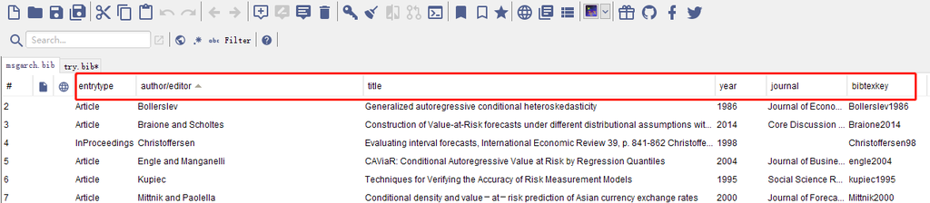

图 4 文献题录

[figure not shown]

图 5 文献题录显示设置

5. 相关设置完成之后，点击菜单栏中的“+”即可新增一条记录，出现图 6 所示的对话框，下面以增加 “加权马尔科夫AR_GARCH_GED模型在降水量中的预测”为例，进行说明，由于该文章属于期刊论文，故选择“Article”, 点击generate进入到下一步,如图 7 所示分别输入作者，题目，期刊，年份之后，jabref界面就会出现图 8 中对应的文章，也可以直接点击“{}Bibtex source”,将图 9 中内容直接复制到其对应的条框中,pages信息在optional fields选项下填写。（注：在百度学术搜索出文章以后，点击“引用-bibtex”，即可出现如图 9所示的内容；英文文献可用链接“https://www.bing.com/academic?mkt=zh-CN&mkt=zh-CN” 进行搜索，搜索成功以后点击“Download citation”即可下载参考bibtex。）

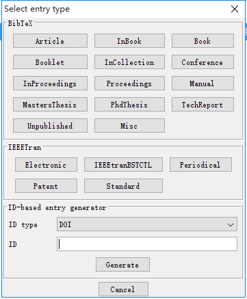

图 6 新增bib文件

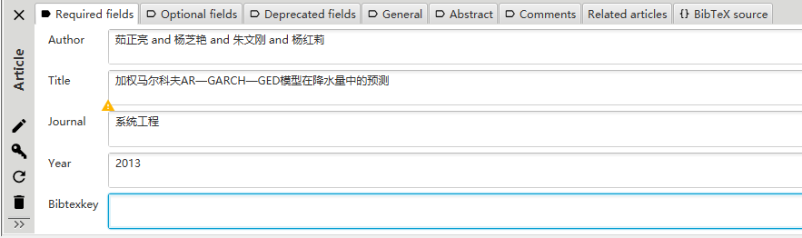

图 7 填写文献信息

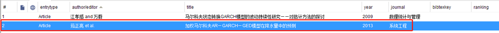

图 8 文献信息生成

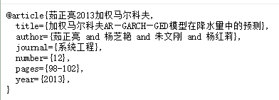

图 9 百度学术

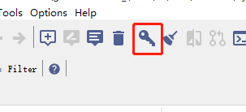

图 10 钥匙

注：jabref设置环境变量

安装rapidee，鼠标右键点击user variables窗口，点击add variable，在弹出的窗口中variable name输入JAVA_HOME，点击ok，返回user variables窗口，输入jre所在的路径。需要注意的是jabref 和jre需要保持相同的版本，都安装32位或者64位（建议64位）的。

## 10.2 整理bib文件注意事项

**注意:不再推荐使用此方法，直接使用下面的“如何运用VSCODE在论文中引用参考文献”**

1.在Jabref里面整理好bib文件以后，依次导出Bibfile.bib文件和Bibfile.csv文件;

2.转码：若Jabref输出的csv文件乱码，则用记事本打开该csv文件，并选择编码方式为ANSI，如图 11 所示。 excel打开csv文件默认编码方式为uf-8，所以一旦出现乱码，可以选择ANSI转码。

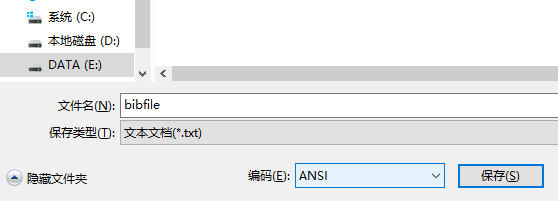

图 11 ANSI编码

3.打开转码后的csv文件，增加用于论文参考文献引用的bibtexkey列,即 `[@authoryear]` ，整理好之后，可直接在论文中相应位置复制粘贴，不易出错。如图 12 所示，引用bibtexkey的位置即为论文中注明参考文献顺序的角标的位置。

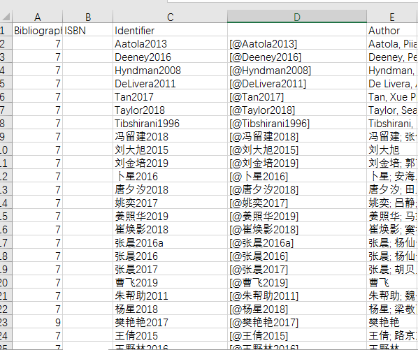

图 12 bibtexkey

## 10.3 如何运用VSCODE在论文中引用参考文献

1. 在所创建的项目中添加上面生成的`Bibfile.bib`文件；
2. 通过VSCODE中的设置获得参考文献自动补全功能。

打开VSCODE的设置选项(可以通过快捷键:英文状态下`ctrl+,`打开或者点击`文件-首选项-设置` 打开),输入`suggest tr`,在弹出的选项中勾选第一条“控制在键入触发字符后是否自动显示建议”。这里的触发字符即为`@`,勾选该选项表示在引用参考文献时，只要当光标停在`[@]`的`@`后面,系统会自动弹出所有“Bibfile”中的“key”,然后用户选择要引用的参考文献即可。通过自动输入可以防止输入错误,而且使用快捷。

3.在Rmd文件末尾加

[output not shown]

**注:** 引用时,参考文献必须要有`[]`才能起作用；引用的时候要有空格然后再引用；`@`的时候如果不出来参考文献列表,用快捷键`ctrl+'`,正确的示例是:`text [@bibkey]`.

## 10.4 参考文献列出所有bib文件中条目方法

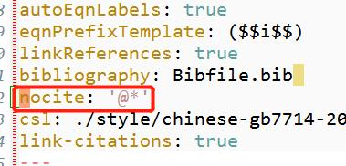

图 13 notice

# 11 Equalx的设置和用法

下载Equalx，打开equalx.exe，菜单栏点击edit→prefrences→Advanced，点击pdflatex后的change，找到pdflatex.exe所在的路径（基本为：./texlive/2014/bin/win32/pdflatex.exe，.表示texlive所在的路径，注：装Equalx之前需要下载texlive），之后点击ghostscript后的change，找到gswin32c.exe所在的路径（注：修改之前需要下载gs）,如图14 所示。

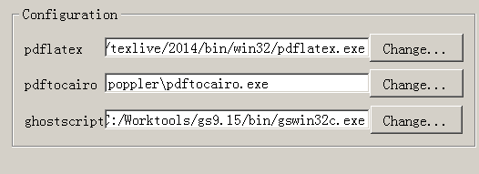

图 14 Equalx安装

edit→prefrences→editor，family选择Consolas，size选择14，字体可以调大一点

edit→prefrences→Preview，Automatic after □ milliseconds，□中输入5000

在编辑框中输入 `\alpha+\hat{\beta}` 就会显示出公式，此软件的意义在于，当输入 `\a`时，就会出现 `\alpha` 等以 `\a` 开头的字母，选中自己所需要的直接enter即可，会自动补全，避免记不住markdown中公式一直看文档。还可以通过点击上面的符号直接输入。对于比较复杂的公式，可以先在这里面输入，然后把latex代码复制到rmd中。

# 12 Mathtype的设置和用法

1. 首先下载mathtype，将其嵌套到word中去，操作成功之后word菜单栏会出现mathtype；
2. 点击mathtype中的convert equations,设置相关属性，勾选Equation Type to convert模块的前两项和第四项，Range模块的“whole document”,在Convert equation to模块下的“Text using MathType translator” 选择“LaTex 2.09 and lator”，如图 15 所示，设置完成以后点击convert就能将word 文档中的公式转化为LaTex公式。注：若安装不成功，卸掉重新安装mathtype即可。

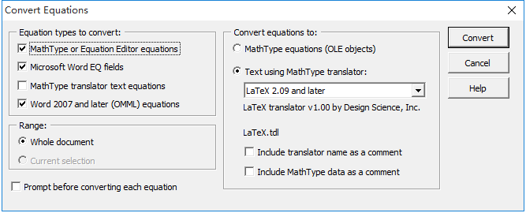

图 15 Mathtype安装

# 13 Rstudio生成bookdown pdf步骤

1. 点击菜单 build -> config build tools…
2. site directory 要设置为 index.rmd 所在的文件夹，如图 16 所示，设置好确认即可。

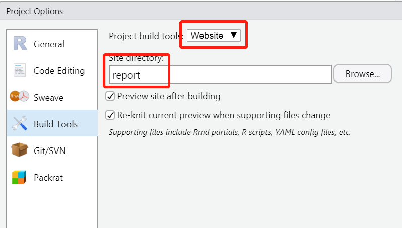

图 16 Build Tools设置

3. 然后点击右上角的build按钮,点击Build Book，选择第二个，如图 17即可生成pdf。

[figure not shown]

图 17 bookdown选择

注意：出错后要删除gamm main.md 文件，再重新build.

# 14 参考文献